# Introduction to SC19060

Minhui Zhu

## Overview

_SC19060__ is a simple R package has twu functions.The first function is used to make up missing values with median. The second funtion is used to generate the Cauchy distribution by Metropolis sampler.

In the data that we collect, there will be missing values. How to deal with these missing values is a common problem. We can fill in the missing value according to the similarity between samples. The following code shows that we can fill in the missing value by median, because the median is a good indicator of data centre trends.

```r
MakeupMissingValue<-function(data)
{
  for(i in seq(ncol(data)))
    if(any(a<-is.na(data[,i])))
    {
      data[a,i]<-median(data[,i],na.rm = T)
    }
  data
}
```

The basic idea of Metropolis sampler is that we can if we want to take a sample of a more complex distribution, we can sample from a known simpler distribution first, and then accept this sample as an approximate sample of the target distribution with a certain probability. The following code shows that how to generate Cauchy distribution by using Metropolis sampler.

```r
Metro.Cauchy <- function(sigma, x0, N) {
  x <- numeric(N)
  x[1] <- x0
  u <- runif(N)
  k <- 0
  for (i in 2:N) {
    y <- rnorm(1, x[i-1], sigma)
    if (u[i] <= (1/(pi*(1+y^2))) / (1/(pi*(1+x[i-1]^2))))
      x[i] <- y else {
        x[i] <- x[i-1]
        k <- k + 1
      }
  }
  return(list(x=x, k=k))
}
```

## 2019/09/20

Example 1

```r
ctl<-c(7.82,8.41,7.39,9.02,7.62,8.27,7.93,7.26,8.53,7.74)
trt<-c(6.54,5.73,6.38,6.36,6.93,7.05,5.53,6.75,6.87,5.76)
group<-gl(2,10,20,labels=c("Ctl","Trt"))
weight<-c(ctl,trt)
lm.D9<-lm(weight~group)
summary(lm.D9)$coef
```

```
##             Estimate Std. Error   t value     Pr(>|t|)
## (Intercept)    7.999  0.1734309 46.122115 3.837721e-20
## groupTrt      -1.609  0.2452683 -6.560162 3.653059e-06
```

Example 2

```r
knitr::kable(head(CO2))
```

| Plant | Type | Treatment | conc | uptake |
| --- | --- | --- | --- | --- |
| Qn1 | Quebec | nonchilled | 95 | 16.0 |
| Qn1 | Quebec | nonchilled | 175 | 30.4 |
| Qn1 | Quebec | nonchilled | 250 | 34.8 |
| Qn1 | Quebec | nonchilled | 350 | 37.2 |
| Qn1 | Quebec | nonchilled | 500 | 35.3 |
| Qn1 | Quebec | nonchilled | 675 | 39.2 |

Example 3

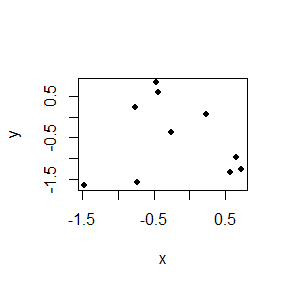

```r
x<-rnorm(10)
y<-rnorm(10)
sunflowerplot(x,y)
```

Example 4

```r
#par(mfrow=c(2,2))
#plot(CO2)
```

## 2019/09/29

##Answer

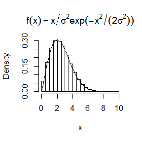

```r
n<-1e5
m<-numeric(n)
u<-runif(m)
sigma<-2
x<-sqrt(-2*sigma^2*log(1-u))
hist(x,prob=TRUE,main = expression(f(x)==x/sigma^2*exp(-x^2/(2*sigma^2))))
y<-seq(0,8,.1)
lines(y,y/sigma^2*exp(-y^2/(2*sigma^2)))
```

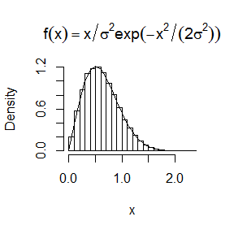

```r
n<-1e5
m<-numeric(n)
u<-runif(m)
sigma<-0.5
x<-sqrt(-2*sigma^2*log(1-u))
hist(x,prob=TRUE,main = expression(f(x)==x/sigma^2*exp(-x^2/(2*sigma^2))))
y<-seq(0,2,.1)
lines(y,y/sigma^2*exp(-y^2/(2*sigma^2)))
```

##Question Generate a random sample of size 1000 from a normal location mixture. The components of the mixture have N(0, 1) and N(3, 1) distributions with mixing probabilities p1 and p2 = 1 − p1. Graph the histogram of the sample with density superimposed, for p1 = 0.75. Repeat with different values for p1 and observe whether the empirical distribution of the mixture appears to be bimodal. Make a conjecture about the values of p1 that produce bimodal mixtures.

##Answer

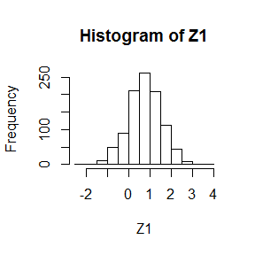

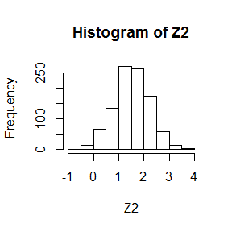

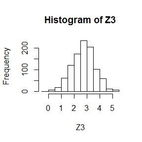

```r
n<-1000
X1<-rnorm(n,0,1)
X2<-rnorm(n,3,1)
Z1<-0.75*X1+0.25*X2
Z2<-0.5*X1+0.5*X2
Z3<-0.1*X1+0.9*X2
#par(mfrow=c(1,3))
hist(Z1);hist(Z2);hist(Z3)
```

##Question Write a function to generate a random sample from a Wd(Σ, n) (Wishart)distribution for n>d + 1 ≥ 1, based on Bartlett’s decomposition.

##Answer

```r
d<-4
n<-6
x<-c(2,1,1,1,1,2,1,1,1,1,2,1,1,1,1,2)
C<-matrix(x,nrow = 4,ncol = 4)
L<-t(chol(C))
#get a lower triangular
sigma<-L%*%t(L)
#since L is a lower triangular, so sigma can do the Choleski factorization
c1<-sqrt(rchisq(1,6))
c2<-sqrt(rchisq(1,5))
c3<-sqrt(rchisq(1,4))
c4<-sqrt(rchisq(1,3))
n21<-rnorm(1)
n31<-rnorm(1)
n32<-rnorm(1)
n41<-rnorm(1)
n42<-rnorm(1)
n43<-rnorm(1)
h<-c(c1,n21,n31,n41,0,c2,n32,n42,0,0,c3,n43,0,0,0,c4)
T<-matrix(h,nrow = 4,ncol = 4)
#T is a lower triangular 4*4 random matrix
A<-T%*%t(T)
X<-L%*%A%*%t(L)
X
```

```
##            [,1]      [,2]      [,3]       [,4]
## [1,]  5.2507551 -4.516737 -5.448067  0.6376369
## [2,] -4.5167373 11.646261  9.721826  4.0798260
## [3,] -5.4480666  9.721826 12.765862  2.9097402
## [4,]  0.6376369  4.079826  2.909740 24.1477179
```

## 2019/10/11

# 5.1

Compute a Monte Carlo estimate of
$$\int_{0}^{\pi / 3} \sin t d t$$
and compare your estimate with the exact value of the integral.

# Answer

First, consider that 0 and
$$\pi / 3$$
are finite, we can set a equal to 0, b equal to $\pi / 3$, $h(t)$ equal to $sinT$, $g(t)$ equal to
$$\frac{\pi}{3}\sin t$$
, then
$$\int_{a}^{b} h(t) d t=\int_{a}^{b} g(t) \frac{1}{b-a} d x=E[g(t)]$$
where
$$T \sim U(a, b), g(t)=(b-a) h(t)$$
. Second, use a frequency to approximate the expectation (Strong Law of Large Number):
$$\frac{1}{m} \sum_{i=1}^{m} g\left(X_{i}\right)$$
wherer $X_1$,…,$X_m$ are iid copies of X and m is a sufficiently large integer.

```r
m<-1e4;t<-runif(m,min = 0,max = pi/3)
theta.hat<-mean(sin(t))*(pi/3)
print(c(theta.hat,cos(0)-cos(pi/3)))
```

```
## [1] 0.5026819 0.5000000
```

From the result, Monte Carlo method is relatively accurate.

# 5.10

Use Monte Carlo integration with antithetic variables to estimate
$$\int_{0}^{1} \frac{e^{-x}}{1+x^{2}} d x$$
and find the approximate reduction in variance as a percentage of the variance without variance reduction.

# Answer

```r
MC.Phi <- function(R = 10000, antithetic = TRUE) {
u <- runif(R/2)
if (!antithetic) v <- runif(R/2) else
v <- 1 - u
u <- c(u, v)
cdf <- numeric(length(5))
g <- exp(-u)/(1+u^2)
cdf<-mean(g)
cdf
}
set.seed(123)
MC1 <- MC.Phi(anti = FALSE)
set.seed(123)
MC2 <- MC.Phi(anti = TRUE)
print(c(MC1,MC2))
```

```
## [1] 0.5263106 0.5246837
```

```r
m <- 1000
MC1 <- MC2 <- numeric(m)
for (i in 1:m) {
MC1[i] <- MC.Phi(R = 1000, anti = FALSE)
MC2[i] <- MC.Phi(R = 1000)
}
print(c(sd(MC1),sd(MC2),(var(MC1) - var(MC2))/var(MC1)))
```

```
## [1] 0.007710907 0.001407317 0.966690144
```

The antithetic variable approach achieved approximately 96.7% reduction in variance.

# 5.15

Obtain the stratified importance sampling estimate in Example 5.13 and compare it with the result of Example 5.10

# Answer

```r
u<-c(0,.2,.4,.6,.8,1)
quintile<--log(1-u*(1-exp(-1)))#generate  quintile
round(quintile,2)
```

```
## [1] 0.00 0.14 0.29 0.48 0.70 1.00
```

```r
M <- 10000 #number of replicates
T2 <- numeric(5)
estimates <- matrix(0, 10, 1)
g <- function(x) {
exp(-x - log(1+x^2)) * (x > 0) * (x < 1) }
u <- runif(M) #f3, inverse transform method
x <- - log(1 - u * (1 - exp(-1)))
fg <- 5*g(x) / (exp(-x) / (1 - exp(-1)))
for (i in 1:10) {
T2[1] <- mean(g(runif(M/4, 0, .14)))
T2[2] <- mean(g(runif(M/4, .14, .29)))
T2[3] <- mean(g(runif(M/4, .29, .48)))
T2[4] <- mean(g(runif(M/4, .48, 70)))
T2[5] <- mean(g(runif(M/4, .70, 1)))
estimates[i, 1] <- mean(T2)
}
apply(estimates, 2, mean)
```

```
## [1] 0.5092268
```

```r
apply(estimates, 2, sd)
```

```
## [1] 0.0002849442
```

## 2019/10/18

# 6.5

Suppose a 95% symmetric t-interval is applied to estimate a mean, but the sample data are non-normal. Then the probability that the confidence interval covers the mean is not necessarily equal to 0.95. Use a Monte Carlo experiment to estimate the coverage probability of the t-interval for random samples of $\chi^{2}(2)$ data with sample size n = 20. Compare your t-interval results with the simulation results in Example 6.4. (The t-interval should be more robust to departures from normality than the interval for variance.)

# Answer

```r
n<-20
alpha<-.05
UCL<-replicate(1000,expr = {
  x<-rchisq(n,df=2)
  mean(x)+var(x)/sqrt(n)*qt(1-alpha,df=n-1)
})
sum(UCL>2)
```

```
## [1] 917
```

```r
mean(UCL>2)
```

```
## [1] 0.917
```

```r
a<-abs(mean(UCL>2)/.95-1)
#calculate the difference between t-interval results and 0.95
```

```r
n<-20
alpha<-.05
UCL<-replicate(1000,expr = {
  x<-rchisq(n,df=2)
  (n-1)*var(x)/qchisq(alpha,df=n-1)
})
sum(UCL>4)
```

```
## [1] 776
```

```r
mean(UCL>4)
```

```
## [1] 0.776
```

```r
b<-abs(mean(UCL>4)/.95-1)
# calculate the difference between the results in example6.4 with 0.95
```

```r
print(c(a,b))
```

```
## [1] 0.03473684 0.18315789
```

Apparently, the t-interval is more robust to departures from normality than the interval for variance.

# 6.6

Estimate the 0.025, 0.05, 0.95, and 0.975 quantiles of the skewness $\sqrt{b_{1}}$ under normality by a Monte Carlo experiment. Compute the standard error of the estimates from (2.14) using the normal approximation for the density (with exact variance formula). Compare the estimated quantiles with the quantiles of the large sample approximation $\sqrt{b_{1}} \approx N(0,6 / n)$.

# Answer

```r
n<-1e4
q<-c(.025,.05,.95,.975)
sk<-replicate(1000,expr = {
x<-rnorm(n)
xbar<-mean(x)
v3<-mean((x-xbar)^3)
v2<-var(x)
v3/(v2^(3/2)) # the skewness
})
q1<-quantile(sk,q)
q2<-qnorm(q,0,sqrt(6/n))
# estimate the 0.025,0.05,0.95,0.975 quantiles of the skewness under normality
print(round(rbind(q1,q2),5))
```

```
##        2.5%       5%     95%   97.5%
## q1 -0.04912 -0.03981 0.04237 0.04874
## q2 -0.04801 -0.04029 0.04029 0.04801
```

```r
q<-c(.025,.05,.95,.975)
sd<-var<-numeric(4)
for (i in 1:4) {
  var[i]<-q[i]*(1-q[i])/(n*dnorm(q1[i],0,sqrt(6*(n-2)/((n+1)*(n+3))))^2)
  sd[i]<-sqrt(var[i])
}
print(sd)
```

```
## [1] 0.0007164870 0.0005014469 0.0005975458 0.0006947495
```

## 2019/11/01

# 6.7

Estimate the power of the skewness test of normality against symmetric$\operatorname{Beta}(\alpha, \alpha)$distributions and comment on the results. Are the results different for heavy-tailed symmetric alternatives such as t(ν)?

# Answer

```r
#compute the sample skewness statistic
sk<-function(x){
  xbar<-mean(x)
  m3<-mean((x-xbar)^3)
  m2<-mean((x-xbar)^2)
  return(m3/m2^1.5)
}
```

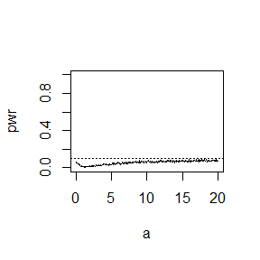

```r
alpha<-.1
n<-30 #sample sizes
m<-2500 #number of replicates
a<-c(seq(.1,20,.1)) #the parameter of beta distribution
N<-length(a)
pwr<-numeric(N)
cv<-qnorm(1-alpha/2,0,sqrt(6*(n-2)/((n+1)*(n+3))))
#critical value  for the skewness test
for (i in 1:N) {
  sktests<-numeric(m)
  for (j in 1:m) {
    x<-rbeta(n,a[i],a[i])
    sktests[j]<-as.integer(abs(sk(x))>=cv)
  }
  pwr[i]<-mean(sktests)
}
#plot power vs a
plot(a,pwr,type = "l",
     xlab = bquote(a),ylim = c(0,1))
abline(h=.1,lty=3)
se<-sqrt(pwr*(1-pwr)/m)
lines(a,pwr+se,lty=3)
lines(a,pwr-se,lty=3)
```

From we can see that the power of the skewness test of normality against symmetric $\operatorname{Beta}(\alpha, \alpha)$ is very low.

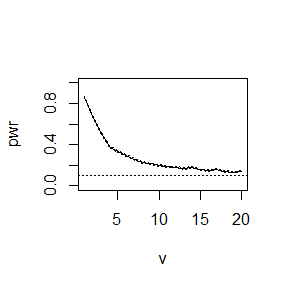

```r
alpha<-.1
n<-30 #sample sizes
m<-2500 #number of replicate
v<-c(seq(1,20)) #the parameter of t distribution
N<-length(v)
pwr<-numeric(N)
cv<-qnorm(1-alpha/2,0,sqrt(6*(n-2)/((n+1)*(n+3))))
#critical value  for the skewness test
for (i in 1:N) {
  sktests<-numeric(m)
  for (j in 1:m) {
    x<-rt(n,v[i])
    sktests[j]<-as.integer(abs(sk(x))>=cv)
  }
  pwr[i]<-mean(sktests)
}
#plot power vs v
plot(v,pwr,type = "l",
     xlab = bquote(v),ylim = c(0,1))
abline(h=.1,lty=3)
se<-sqrt(pwr*(1-pwr)/m)
lines(v,pwr+se,lty=3)
lines(v,pwr-se,lty=3)
```

From the plot we can see that the power of the skewness test of normality against t(v) is better than $\operatorname{Beta}(\alpha, \alpha)$

# 6.A

Use Monte Carlo simulation to investigate whether the empirical Type I error rate of the t-test is approximately equal to the nominal significance level $\alpha$, when the sampled population is non-normal. The t-test is robust to mild departures from normality. Discuss the simulation results for the cases where the sampled population is (i)$\chi^{2}(1)$, (ii) Uniform(0,2), and (iii) Exponential(rate=1). In each case, test $H_{0}: \mu=\mu_{0}$ vs $H_{0}: \mu \neq \mu_{0}$, where $\mu_{0}$ is the mean of $\chi^{2}(1)$, Uniform(0,2), and Exponential(1), respectively.

# Answer

```r
n<-20
alpha<-.05
mu0<-1
m<-10000 #number of replicates
p<-numeric(m) #storage for p-value
```

```r
for (j in 1:m) {
  x<-rchisq(n,1) #sample population is Chisq(1)
  ttest<-t.test(x,alternative = "greater",mu=mu0)
  p[j]<-ttest$p.value
}
p.hat<-mean(p<alpha)
se.hat<-sqrt(p.hat*(1-p.hat)/m)
print(c(p.hat,se.hat))
```

```
## [1] 0.012200000 0.001097778
```

```r
for (j in 1:m) {
  x<-runif(n,0,2) #sample population is Uniform(0,2)
  ttest<-t.test(x,alternative = "greater",mu=mu0)
  p[j]<-ttest$p.value
}
p.hat<-mean(p<alpha)
se.hat<-sqrt(p.hat*(1-p.hat)/m)
print(c(p.hat,se.hat))
```

```
## [1] 0.048100000 0.002139775
```

```r
for (j in 1:m) {
  x<-rexp(n,1) #sample population is Exponential(1)
  ttest<-t.test(x,alternative = "greater",mu=mu0)
  p[j]<-ttest$p.value
}
p.hat<-mean(p<alpha)
se.hat<-sqrt(p.hat*(1-p.hat)/m)
print(c(p.hat,se.hat))
```

```
## [1] 0.018000000 0.001329511
```

From the result we can see that the empirical Type I error rate of the t-test is approximately equal to the nominal significance level $\alpha$ when the sample population is Uniform(0,2), while the empirical Type I error rate of the t-test leads to great deviation if the sample population is Chisq(1) or Exponential(1).

# Discussion

If we obtain the powers for two methods under a particular simulation setting with 10,000 experiments: say, 0.651 for one method and 0.676 for another method. Can we say the powers are different at 0.05 level? (1)What is the corresponding hypothesis test problem?

(2)What test should we use? Z-test, two-sample t-test, paired-t test or McNemar test?

(3)What information is needed to test your hypothesis?